# Testes de hipótese x ICs

Problema 4 - Checkpoint 4

## Descrição dos dados

Esse estudo tem como base uma *amostra* dos dados da atividade global do [GitHub](https://github.com/). Os dados contém a contagem de quantas pessoas editaram arquivos com cada extensão de arquivo em cada dia de 2016 e em alguns meses de 2017.

Para responder as questões desse estudo serão necessárias algumas transformações nos dados, de modo a obter a data completa e o dia da semana de cada observação.

```r
dados <- read.csv("github-users-committing-filetypes.csv")
```

```r
dados <- dados %>%
  unite("data", the_year, the_month, month_day, sep = "-") %>%
  mutate(data = as.Date(strptime(data, "%Y-%m-%d"))) %>%
  mutate(mes = month(data))
```

As questões desta análise são de cunho temporal, assim sendo, a visualização abaixo pode lhe ajudar a entender o comportamento da amostra com a qual estamos lidando.

É possível observar vários períodos de tempo diferentes neste gráfico, divirta-se!

```r
dados_ <- dados %>%
  select(-c(file_extension, mes)) %>%
  group_by(data) %>%
  summarise(users_tot = sum(users)) %>%
  remove_rownames %>%
  column_to_rownames(var="data") %>%
  as.xts()

highchart(type = "stock") %>%
  hc_title(text = "Timeline da Atividade Geral do Github") %>%
  hc_add_series(dados_)
```

[interactive chart not shown]

## Testes de hipótese vs. Intervalos de confiança

A análise anterior o que fizemos foi determinar **intervalos de confiança** para fazermos afirmações sobre a população que estavamos estudando com um certo nível de confiança (em geral 95%).

Aqui, buscamos responder duas perguntas acerca da atividade global do Github usando **testes de hipótese**.

No nosso estudo anterior respondemos à questão: **Existe diferença na produtividade no primeiro e no segundo semestre de 2016?**, tentaremos responder essa mesma pergunta usando testes de hipótese.

Com intevalos de confiança usamos a mediana como estatística para respondar à pergunta e obtivemos:

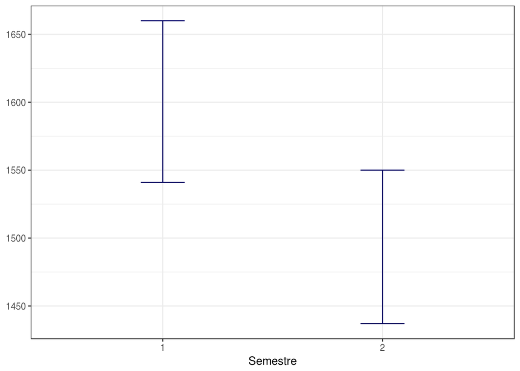

```r
dados.semestre <- dados %>%
  filter(substr(data, 0,  4) == "2016") %>%
  mutate(Sem1 = mes <= 6) %>%
  select(users, mes, Sem1, data)

b_sem1 <- bootstrap(dados.semestre %>%
                filter(Sem1), median(users))

sem1.CI <- CI.percentile(b_sem1, probs = c(.025, .975))


b_sem2 <- bootstrap(dados.semestre %>%
                filter(!Sem1), median(users))

sem2.CI <- CI.percentile(b_sem2, probs = c(.025, .975))


df.sem <- data.frame(rbind(sem1.CI,
                       sem2.CI))

df.sem$Semestre = row.names(df.sem)

df.sem %>%
  ggplot(aes(x = Semestre, ymin = X2.5., ymax = X97.5.)) +
  geom_errorbar(width = .2, color = "#000066")
```

Percebemos que há uma grande difença entre o primeiro e o segundo semestre, mas, a intersecção entre os gráficos nos faz não ter certeza se a produtividade é realmente maior nos primeiros seis meses do ano, assim, faremos uso da difença para determinarmos o intervalo de confiança e o quanto ele pode ser útil enquanto aquisição de informação sobra a população.

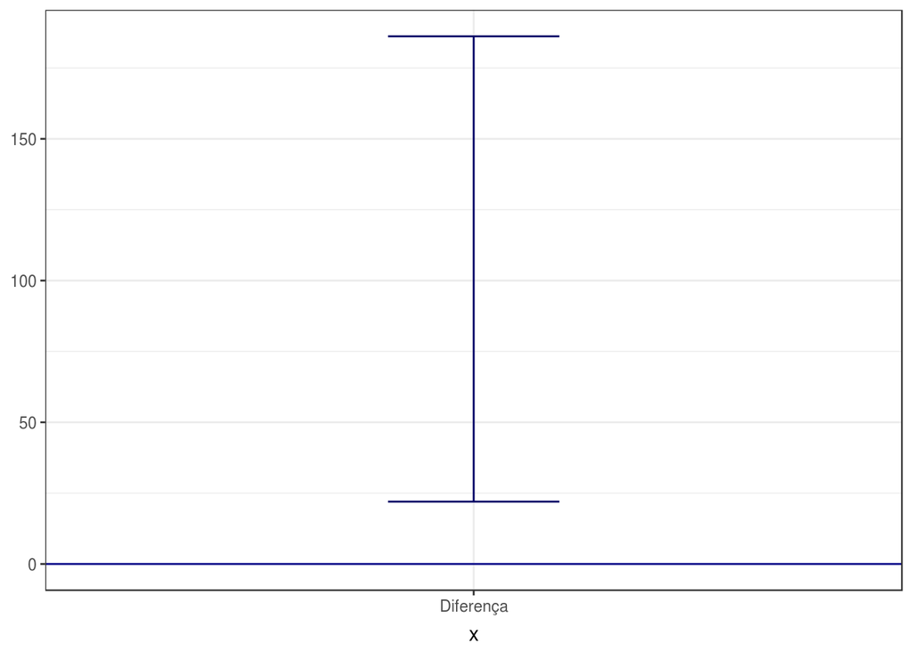

```r
b_diff <- bootstrap2(data = (dados.semestre %>%
                               filter(Sem1))$users,
                     data2 = (dados.semestre %>%
                               filter(!Sem1))$users,
                     median)

b_diff.ci <- CI.percentile(b_diff, probs = c(.025, .975))

data.frame(b_diff.ci) %>%
  ggplot(aes(x = "Diferença", ymin = X2.5., ymax = X97.5.)) +
  geom_errorbar(width = .2, color = "#000066") +
  geom_hline(yintercept = 0, colour = "darkblue")
```

A diferença nos faz confirmar nossas suspeitas facilmente, uma vez que o intervalo encontrado não inclui o zero, logo, podemos afirmar com 95% de confiança que a atividade no Github é maior no primeiro semestre do ano. O intervalo encontrado é de 22, 186.186946. Em outras palavras, a diferença de produtividade entre os semestres é relevante e maior atividade está no primeiro semestre.

O estudo usando intervalos de confiança, que acabamos de fazer, nos permite não somente verificar a existência de difernça entre as medianas dos dados mas também mensurar que intervalo é este.

A seguir responderemos a mesma pergunta mas usando Testes de hipótese, para isso, é fundamental introduzir alguns conceitos importantes:

**Hipótese Nula (H0)**: É uma hipótese que quando realizamos um teste de hipóteses tentamos provar que é falsa, pois geralmente afirma que não há relação entre os fenômenos em estudo.<sup>[1](https://pt.wikipedia.org/wiki/Hip%C3%B3tese_nula)</sup> No nosso caso a hipótese nula será *Não há diferença de produtividade entre os semestres do ano.*

**Hipótese Alternativa**: É a hipotese *rival* de H0, que busca provar o contrário do que foi eunciado por ela.<sup>[2](https://pt.wikipedia.org/wiki/Hip%C3%B3tese_nula)</sup> A nossa hipótese alternativa é que *Há diferença significativa na produtividade entre os semestres*.

**P-valor**: Também denominado nível descritivo do teste, é a probabilidade de que a estatística do teste (como variável aleatória) tenha valor extremo em relação ao valor observado (estatística) quando a hipótese H0 é verdadeira. Em outras palavras é a chance de obter uma associação como a que foi observada caso a hipótese nula seja verdadeira.

Agora que já conhecemos os termos mais comuns ligados ao teste de hipótese podemos realizá-lo e analizá-lo com mais propriedade.

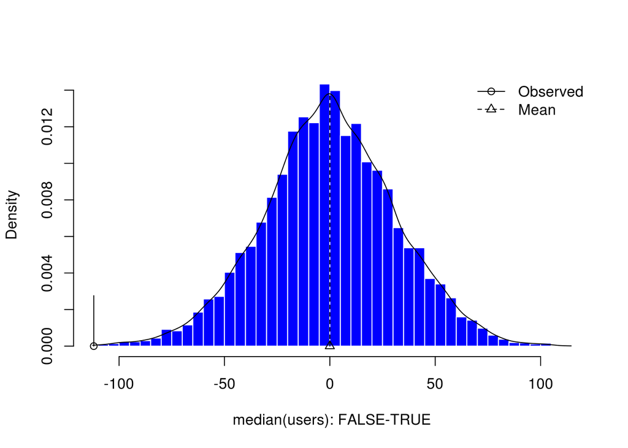

```r
options("scipen"=999)
set.seed(123)
perm <- permutationTest2(data = dados.semestre, statistic = median(users), treatment = Sem1)
hist(perm)
```

Em geral, o nível de significância ($\alpha$) usado no teste de hipóteses é de 5%, deste modo, de o P-valor for menor que $\alpha$ rejeitamos H0, mas se este for maior não rejeitamos a hipótese nula.

Em nosso caso o valor obtido para P-valor é de 0.0006, que é bastante abaixo do nível de significância estabelecido (0.05). Logo, podemos interpretar esse valor da seguinte forma:

Em uma realidade em que não existe diferença significativa na produtividade entre os semestres do ano (H0 é verdadeira) 0.0006 é a chance de obtermos uma associação como a que obtivemos.

Como P-valor está bastante *distante* de $\alpha$ estamos também distantes de H0 e com isso, temos bastante confiança para rejeitá-la e afirmar que existe sim, diferença significativa na produtividade entre os períodos.

Vale ressaltar que P-valor não nos dá informações acerca do intervalo de confiança no qual está contido a estatística que calculamos ou mesmo o nível de confiança que poderíamos ter, informações como estas são obtidas através de intervalos de confiança.